# Introduction to survey sampling with R

## Why sampling?

- In most cases a complete enumeration is not possible, but if done properly, properties of a population can be inferred from a randomly selected sample

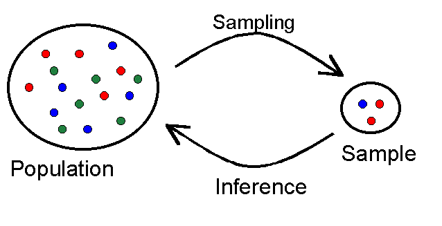

## General approach

- Overall planning of the survey
- Define the population of interest
- Constructing the sampling frame
- Choice of sampling design
- Selection of sample
- Data collection
- Data editing and imputation
- Estimation
- Dissemination

## Sampling error

- The fact that not all units go into the inference introduces an uncertainty about the estimates which we call **sampling error**
- The sampling error is a consequence of the fact that we would get (slightly) different results if we could **repeatedly draw** new samples
- Given a sampling design the sampling error will generally be lower if the units in the population are alike (**low variance**) or the sample size is bigger
- **Note:** For the same sample size the sampling error will be smaller if a suitable design is chosen

## Simple demonstration of sampling error

```r
# synthetic population
set.seed(236542)
N <- 1000
yi <- rnorm(N, mean=5000, s=1000)

# attributes at population level
mean (yi)
```

```
## [1] 4965.94
```

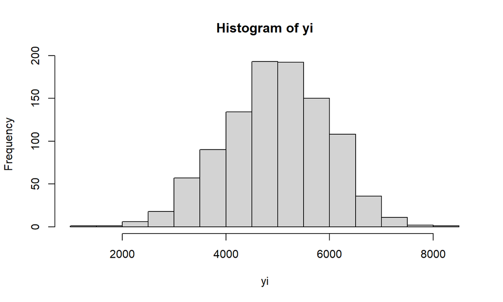

```r
hist (yi)
```

```r
# take a sample of size n
n <- 10
s <- sample(1:length(yi), n, replace = FALSE)

# mean of sample
mean(yi[s])
```

```
## [1] 4729.023
```

```r
mean(yi)
```

```
## [1] 4965.94
```

```r
# repeat sampling K times
K <- 1000
mu_hat <- numeric(K)

for (i in 1:K){
  s <- sample(1:length(yi), n, replace = FALSE)
  mu_hat[i] <- mean(yi[s])
}

mean(mu_hat)
```

```
## [1] 4964.755
```

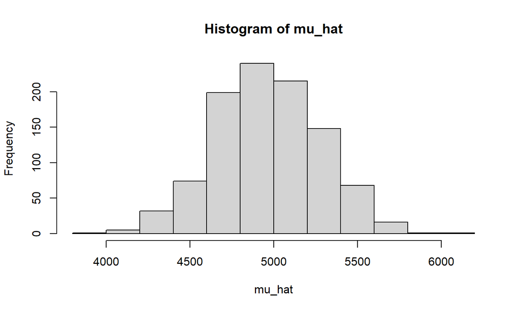

```r
# sampling distribution
hist(mu_hat)
```

- Playing with population variance and sample size…

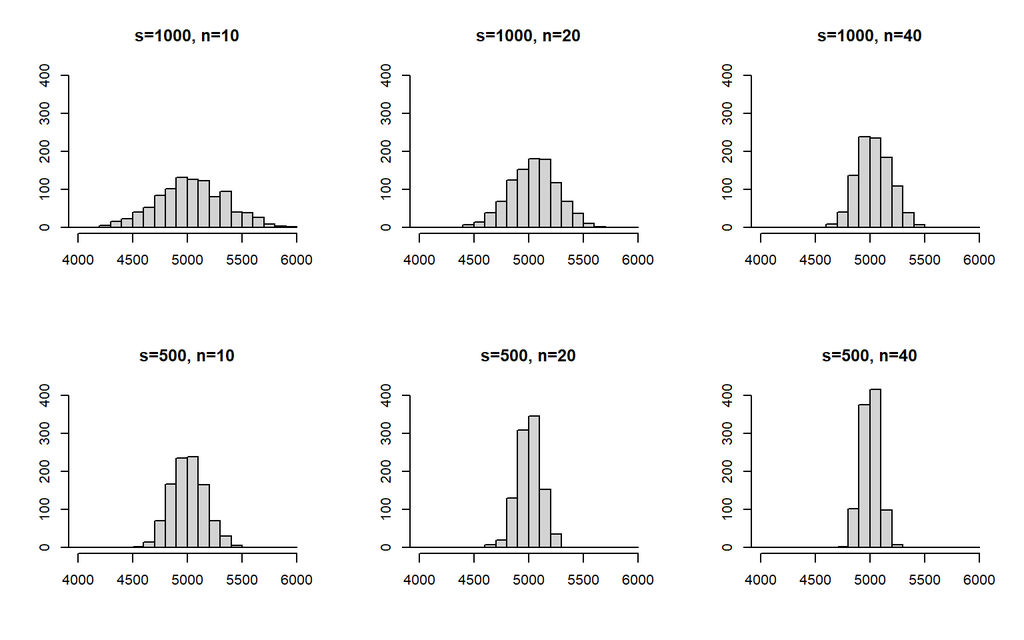

## Representativity

- Representativity is **not** dependent upon the sample size
- For a sample to be representative, **all** units must have the **possibility** to be in the sample (inclusion probability > 0)
- The intuitive meaning of a **representative** sample normally is that has a certain size, but also that the marginal properties of the sample resemble those of the population
  - Certain procedures exist that makes a **balanced sample** in exactly this meaning
  - A balanced sample is also said to be **well spread** and actual measures for this have been constructed (see eg. Grafström and Tillé)

## SRS: Simple random sampling

- SRS is one of the fundamental building block
- Assume a population of size \(N\) and that a sampling frame (a list of units) is available
- Randomly select \(n\) out of \(N\) units without replacement
- The implied inclusion probability is \(\pi = n/N\)
- Note: This is **equivalent** to considering the \(C(N,n)\) possible \(n\)-subsets and randomly select one of these as the sample!

## SRS and the HT-estimator

- Assume a population with \(N\) units and that the units have some quantitative attribute \(y\)
- We seek to estimate the total sum of this attribute over the entire population: \[ \tau_y = \sum _{j=1}^N y_j\]
- For this purpose we draw a sample of size \(n\) by **simple random sampling** (SRS)
- The inclusion probability \(\pi\) for each unit is \(n/N\)
- We can now estimate \(\tau_y\) by applying the Horvitz-Thomson estimator
- Every single observation from the sample is weighted by the inverse of the inclusion probability: \[\hat{\tau}_y = \sum_{j=1}^n \frac{N}{n}y_j\]
- The **variance** of \(\hat{\tau}_y\) is given by \[ V(\hat{\tau}_y) = N^2 (1-\frac{n}{N}) \frac{\hat{s}^2}{n} \] where \(\hat{s}^2\) is an estimate for the variance of \(y\) in the population \(V(y) = \sigma^2\)
- The factor \((1-n/N)\) is the **finite population correction** — this quantity can be ignored when the sampling fraction \(n/N\) is very small
- We normally estimate \(s\) from the sample by the **standard deviation** \[ s = \sqrt{\frac{1}{n-1}\sum_{j=1}^{n}(y_i - \bar{y})^2} \]
- Normally we are more interested in the square root of the variance of the estimate — this quantity is called the **standard error**
- The standard error is conveniently measured on the same scale as the estimate
- We can also calculate the **coefficient of variation** (or relative standard error) \[ CV(\hat{\tau}) = \frac{s_\hat{\tau}}{\hat{\tau}} \]
- Note: If instead we wanted to estimate the mean \(\mu\) of \(y\) in the population then we simply divide by the population size \(N\) which yields \[ \hat{\mu}_y = \frac{1}{N} \hat{\tau}_y = \sum_{i=1}^n \frac{1}{n}y_i \] This is simply the **sample mean**
- Consequently the variance for the estimated mean can be found as \[ V(\hat{\mu}_y) = V(\frac{1}{N}\hat{\tau}_y) = \frac{1}{N^2}V(\hat{\tau}_y) = (1-\frac{n}{N}) \frac{\hat{s}^2}{n} \]
- Note that \(CV(\hat{\tau}) = CV (\hat{\mu}_y)\)

## Application of the HT-estimator in R

- Example from Cochran (pp. 27-28)

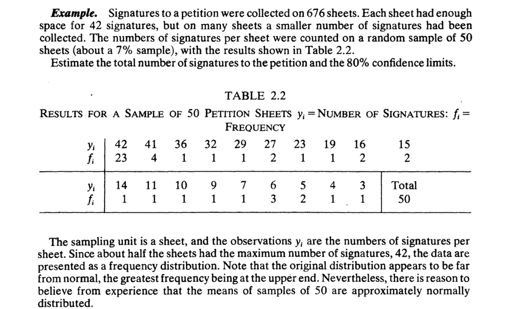

- We start by entering the data, which can be done in any number of ways

```r
yi <- c(rep(42,23), rep(41,4), 36, 32, 29, rep(27,2), 23, 19, rep(16,2),
        rep(15,2), 14, 11, 10, 9, 7, rep(6,3), rep(5,2), 4, 3)
```

- We also need to declare \(N\) and \(n\): The former is **hard coded** while the latter is derived from the \(y_i\)’s

```r
N <- 676
(n <- length(yi))
```

```
## [1] 50
```

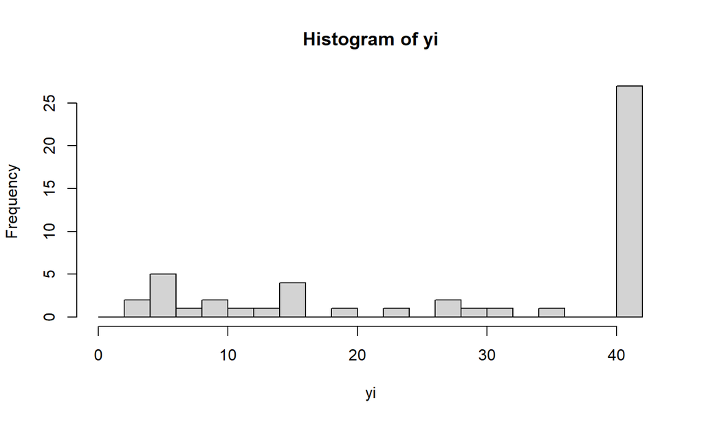

```r
hist(yi, breaks=seq(0,42,2))
```

```r
(Yhat <- N * sum(yi) / n)
```

```
## [1] 19887.92
```

- The 80 pct. confidence limits can be calculated *by hand* as follows

```r
Yhat + c(-1,1) * qnorm(0.9) * N * sd(yi) * sqrt(1-n/N) / sqrt(n)
```

```
## [1] 18103.84 21672.00
```

- This corresponds to the way the calculations are presented in Cochran…

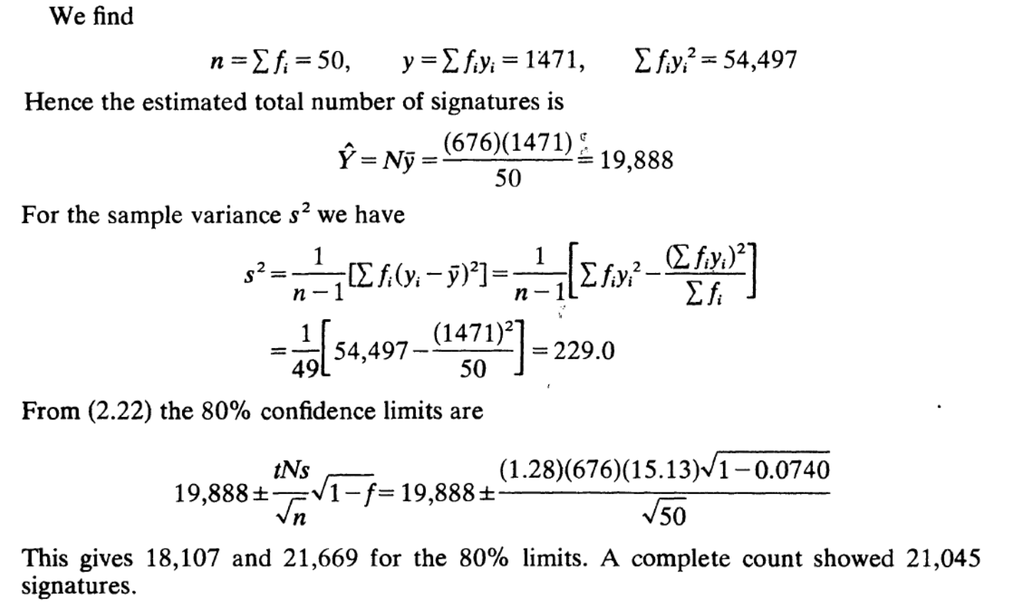

- An easier approach is to use the **survey** package written by Thomas Lumley (@tslumley)

```r
library(survey)
```

- In order to use survey data has to be in a **data frame**

```r
sample.data <- data.frame(i=1:n, y=yi, N=N)
head(sample.data, n=5)
```

```
##   i  y   N
## 1 1 42 676
## 2 2 42 676
## 3 3 42 676
## 4 4 42 676
## 5 5 42 676
```

- We now create a **survey object** using the function `svydesign`
- The object is created by describing the **survey design** and point to the **data**
- In our case the function requires a minimal number of argument since the design is very simple

```r
srs.design <- svydesign(id=~1,
                        fpc=~N,
                        data=sample.data)
```

- There is a summary method for the class of survey objects

```r
summary(srs.design)
```

```
## Independent Sampling design
## svydesign(id = ~1, fpc = ~N, data = sample.data)
## Probabilities:
##    Min. 1st Qu.  Median    Mean 3rd Qu.    Max.
## 0.07396 0.07396 0.07396 0.07396 0.07396 0.07396
## Population size (PSUs): 676
## Data variables:
## [1] "i" "y" "N"
```

- This is **very** useful with more complicated designs
- You can now estimate the total \(\hat{Y}\) in a very simple way – notice that the **standard error** is automatically reported as well

```r
(Yhat <- svytotal(~y, srs.design))
```

```
##   total     SE
## y 19888 1392.1
```

- The requested **confidence limits** can be derived using the standard error, but it is more convenient to use the function made specifically for this purpose

```r
confint(Yhat, level=0.80)
```

```
##       10 %  90 %
## y 18103.84 21672
```